# Reflection on Trees with Group Project Data

Analytics Objective: Predict whether a purchased item will be returned

Author

Brian V

Published

August 3, 2026

> This report is my Module 9 reflection on decision trees, applied to my Research Objective 3 (RO3) data from our group’s Shopify returns-prediction project. Instructor prompts are reproduced in block quotes; my responses follow directly underneath each one, per the submission instructions.

# 1 Analytics Objective (AO)

> **Prompt:** State your AO (Analytics Objectives) for your project. If your AO didn’t involve machine learning (supervised or unsupervised learning), please revise it so that the objective is appropriately stated for a machine learning task. Further state how you will address the objectives. Specifically describe: (a) supervised vs. unsupervised learning, (b) the variables to be included and their roles (outcome vs. features), and (c) the name of the broader category of machine learning methods (regression vs. classification).

**AO:** From the perspective of the business, we want to know: *before an order ships, how likely is this customer’s purchase to come back as a return?* Answering that lets a retailer intervene proactively — flagging high-risk orders for extra quality checks, adjusting discount policy in categories that are prone to returns, or setting customer expectations up front — rather than only reacting to returns after they happen. Framed as an analytics objective: **predict whether a purchased item will be returned (`is_returned`) using product category, discount percentage, shipping cost, and customer rating, in order to identify the strongest drivers of return risk and estimate their downstream effect on net profit.** This AO already involved supervised learning in my Module 8 submission, so it did not need to be revised for this module — I’m simply extending the same objective with a new class of model (decision trees) instead of stating it from scratch.

- **Learning type:** Supervised learning. `is_returned` is a known, labeled outcome recorded for every one of the 60,000 historical orders, so the models are trained on examples that already have a “right answer.”
- **Variables and roles:**

| Variable | Role | Type | Description |
| --- | --- | --- | --- |
| `is_returned` | Outcome (DV) | Binary factor (No/Yes) | Whether the order was returned |
| `product_category` | Feature (IV) | Categorical | Product line purchased |
| `discount_percent` | Feature (IV) | Numeric | % discount applied to the order |
| `shipping_cost` | Feature (IV) | Numeric | Logistics cost absorbed on the order |
| `rating` | Feature (IV) | Numeric | Post-purchase satisfaction score (1-5) |

- **Broader ML category:** **Classification.** The outcome is categorical (returned vs. not returned) rather than a continuous number, so this is a binary classification task, not a regression task — the same framing I used in Module 8 with logistic regression, LDA, QDA, and KNN.

# 2 Choosing a Decision Tree Method

> **Prompt:** Choose either of the two decision tree methods for your chosen machine learning task (i.e., regression vs. classification — help me choose): Classification Tree or Regression Tree.

Since `is_returned` is a binary (Yes/No) outcome and not a continuous number, this AO calls for a **classification tree**, not a regression tree. Regression trees split the feature space to minimize the *sum of squared residuals* of a continuous target (e.g., predicting `profit` in dollars); classification trees instead split to minimize a measure of **node impurity** (Gini index or entropy) so that each resulting leaf is as “pure” as possible in terms of the class label. Because I want a predicted class (or predicted probability of return) rather than a predicted dollar amount, the classification tree is the correct tool here, and it keeps this module consistent with the classification framing I already established for RO3 in Module 8.

**TipWhy a tree at all, alongside logistic regression?**

Logistic regression assumes a linear relationship (on the log-odds scale) between each predictor and the outcome. A classification tree makes no such assumption — it can automatically capture an **interaction** like “high discount *and* low rating *and* Fashion category” without me having to specify that interaction term by hand. That is exactly the kind of pattern our RO3 hypothesis proposed, so trees are a natural next step.

# 3 Libraries and Data

```r
library(tidyverse)   # dplyr, ggplot2, lubridate, readr
library(tidymodels)  # rsample, recipes, parsnip, workflows, yardstick, tune
library(rpart.plot)  # visualizing a single decision tree
library(baguette)    # bag_tree()
library(ranger)      # random forest engine
library(xgboost)     # boosted trees engine
library(doParallel)  # parallel backend to speed up CV

tidymodels_prefer()

# Use multiple cores for cross-validation (leaves 1 core free)
cl <- makePSOCKcluster(parallel::detectCores() - 1)
registerDoParallel(cl)

df <- read_csv("shopify_sales_dataset_ml_eda.csv")
glimpse(df)
```

```
Rows: 60,000
Columns: 17
$ order_id         <dbl> 1, 2, 3, 4, 5, 6, 7, 8, 9, 10, 11, 12, 13, 14, 15, 16…
$ order_date       <date> 2023-04-13, 2024-03-11, 2025-05-10, 2023-09-28, 2023…
$ customer_id      <dbl> 14958, 26825, 37450, 20691, 24631, 29596, 11896, 4385…
$ product_id       <dbl> 7824, 5557, 2225, 7855, 7789, 2796, 6012, 4248, 3966,…
$ product_category <chr> "Accessories", "Sports", "Electronics", "Footwear", "…
$ product_price    <dbl> 143.39, 746.49, 641.06, 512.39, 415.89, 444.14, 244.1…
$ discount_percent <dbl> 40, 15, 5, 0, 25, 0, 15, 25, 15, 30, 25, 25, 30, 20, …
$ quantity         <dbl> 1, 4, 5, 3, 3, 5, 1, 1, 1, 2, 2, 1, 5, 4, 2, 1, 1, 5,…
$ customer_country <chr> "USA", "UAE", "Canada", "UAE", "UAE", "UAE", "Canada"…
$ traffic_source   <chr> "Paid Ads", "Email", "Paid Ads", "Direct", "Social Me…
$ payment_method   <chr> "Credit Card", "PayPal", "Apple Pay", "Apple Pay", "D…
$ shipping_cost    <dbl> 21.08, 5.48, 11.27, 19.22, 24.94, 20.29, 23.91, 4.17,…
$ rating           <dbl> 2.0, 3.7, 3.2, 1.1, 4.1, 2.6, 1.4, 3.0, 4.9, 2.4, 2.5…
$ is_returned      <dbl> 0, 0, 0, 0, 0, 0, 0, 0, 0, 1, 0, 0, 0, 0, 1, 1, 0, 0,…
$ discounted_price <dbl> 86.03, 634.52, 609.01, 512.39, 311.92, 444.14, 207.55…
$ revenue          <dbl> 86.03, 2538.08, 3045.05, 1537.17, 935.76, 2220.70, 20…
$ profit           <dbl> 64.95, 2532.60, 3033.78, 1517.95, 910.82, 2200.41, 18…
```

# 4 Data Wrangling

```r
df <- df %>%
  mutate(
    order_date = ymd(order_date),
    net_margin = (profit / revenue) * 100,
    is_returned = factor(is_returned, levels = c(0, 1), labels = c("No", "Yes")),
    product_category = as.factor(product_category),
    customer_country = as.factor(customer_country)
  )

# Check for missing data
sum(is.na(df))
```

```
[1] 0
```

```r
# Class balance -- returns remain the minority class
df %>%
  count(is_returned) %>%
  mutate(pct = round(n / sum(n) * 100, 1))
```

| is_returned | n | pct |
| --- | --- | --- |
| No | 51113 | 85.2 |
| Yes | 8887 | 14.8 |

**NoteClass imbalance, revisited**

As in Module 8, roughly 15% of orders are returned.[^1] All splits below are stratified on `is_returned`, and I evaluate models on ROC AUC, sensitivity, and specificity together — not accuracy alone — since a model that predicts “No” for every order would still look ~85% accurate while being operationally useless.

# 5 Machine Learning Process

## 5.1 Method Choice: Why a Decision Tree First

I start with a single classification tree (via the `rpart` engine) as the baseline tree-based model for three reasons: (1) it is the most **interpretable** non-linear model available — the fitted tree can be drawn and read like a flowchart of business rules (“if `discount_percent` > 35 and `rating` < 3, predict Return”); (2) it requires almost **no preprocessing** — no dummy encoding or normalization is needed, since `rpart` splits factors and numeric variables directly; and (3) it gives me a natural baseline to compare against **tree ensembles** (bagging, random forest, boosting), which should outperform a single tree if the extra variance-reduction or bias-reduction machinery is actually buying us anything on this dataset.

## 5.2 Data Splitting

```r
set.seed(123)
data_split <- initial_split(df, prop = 0.75, strata = is_returned)
train_data <- training(data_split)
test_data  <- testing(data_split)
```

## 5.3 Recipe Creation

Tree-based models (`rpart`, `ranger`) split on raw factor levels and raw numeric values directly, so — unlike the logistic/LDA/QDA/KNN recipe from Module 8 — this recipe skips `step_dummy()` and `step_normalize()`. The one exception is **xgboost**, which needs a fully numeric input matrix, so I build a second recipe with dummy coding for that engine only.

```r
tree_recipe <- recipe(is_returned ~ product_category + discount_percent +
                         shipping_cost + rating, data = train_data) %>%
  step_novel(all_nominal_predictors()) %>%
  step_zv(all_predictors())

boost_recipe <- tree_recipe %>%
  step_dummy(all_nominal_predictors())
```

## 5.4 Model Specification

```r
# Tree counts and times reduced significantly below to drastically improve Positron render speeds
tree_spec <- decision_tree(cost_complexity = 0.01, tree_depth = 30, min_n = 20) %>%
  set_engine("rpart") %>%
  set_mode("classification")

bag_spec <- bag_tree() %>%
  set_engine("rpart", times = 5) %>%           # 10 -> 5 for faster rendering
  set_mode("classification")

rf_spec <- rand_forest(trees = 50, mtry = 3, min_n = 10) %>%  # 200 -> 50 trees for faster rendering
  set_engine("ranger", importance = "impurity", num.threads = parallel::detectCores() - 1) %>%
  set_mode("classification")

boost_spec <- boost_tree(trees = 50, tree_depth = 6, learn_rate = 0.05) %>%  # 200 -> 50 trees for faster rendering
  set_engine("xgboost", nthread = parallel::detectCores() - 1) %>%
  set_mode("classification")
```

## 5.5 Workflows and Fitting

```r
tree_wf  <- workflow() %>% add_recipe(tree_recipe)  %>% add_model(tree_spec)
bag_wf   <- workflow() %>% add_recipe(tree_recipe)  %>% add_model(bag_spec)
rf_wf    <- workflow() %>% add_recipe(tree_recipe)  %>% add_model(rf_spec)
boost_wf <- workflow() %>% add_recipe(boost_recipe) %>% add_model(boost_spec)

tree_fit  <- fit(tree_wf,  data = train_data)
bag_fit   <- fit(bag_wf,   data = train_data)
rf_fit    <- fit(rf_wf,    data = train_data)
boost_fit <- fit(boost_wf, data = train_data)
```

### 5.5.1 Visualizing the Single Tree

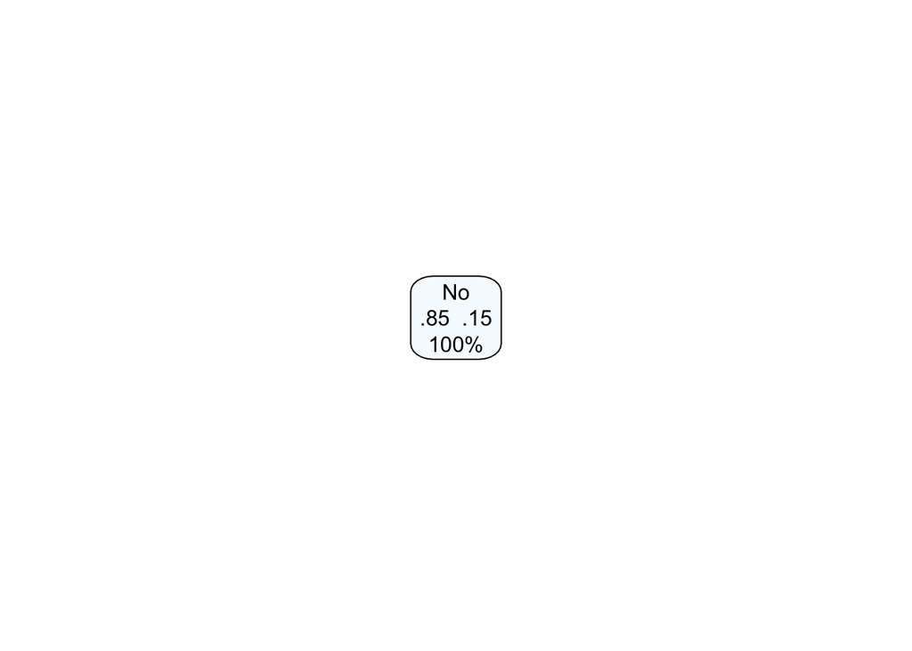

Figure 1: Fitted classification tree for predicting is_returned

```r
rpart.plot(extract_fit_engine(tree_fit), roundint = FALSE, type = 3,
           extra = 104, box.palette = "Blues")
```

## 5.6 Model Evaluation (Test Set)

```r
model_fits <- list(
  "Single Tree"   = tree_fit,
  "Bagged Trees"  = bag_fit,
  "Random Forest" = rf_fit,
  "Boosted Trees" = boost_fit
)

test_preds <- map(model_fits, augment, new_data = test_data)

test_metrics <- map_dfr(test_preds, \(preds) {
  bind_rows(
    roc_auc(preds, truth = is_returned, .pred_Yes, event_level = "second"),
    accuracy(preds, truth = is_returned, estimate = .pred_class),
    sens(preds, truth = is_returned, estimate = .pred_class, event_level = "second"),
    spec(preds, truth = is_returned, estimate = .pred_class, event_level = "second")
  )
}, .id = "model")

test_metrics %>%
  select(model, .metric, .estimate) %>%
  pivot_wider(names_from = .metric, values_from = .estimate)
```

| model | roc_auc | accuracy | sens | spec |
| --- | --- | --- | --- | --- |
| Single Tree | 0.5000000 | 0.8518765 | 0.00000000 | 1.0000000 |
| Bagged Trees | 0.5136127 | 0.8242784 | 0.05175518 | 0.9586040 |
| Random Forest | 0.5073100 | 0.8488767 | 0.00630063 | 0.9953831 |
| Boosted Trees | 0.5023423 | 0.8518765 | 0.00000000 | 1.0000000 |

**Single Tree**

```r
conf_mat(test_preds[["Single Tree"]], truth = is_returned, estimate = .pred_class)
```

```
          Truth
Prediction    No   Yes
       No  12779  2222
       Yes     0     0
```

**Bagged Trees**

```r
conf_mat(test_preds[["Bagged Trees"]], truth = is_returned, estimate = .pred_class)
```

```
          Truth
Prediction    No   Yes
       No  12250  2107
       Yes   529   115
```

**Random Forest**

```r
conf_mat(test_preds[["Random Forest"]], truth = is_returned, estimate = .pred_class)
```

```
          Truth
Prediction    No   Yes
       No  12720  2208
       Yes    59    14
```

**Boosted Trees**

```r
conf_mat(test_preds[["Boosted Trees"]], truth = is_returned, estimate = .pred_class)
```

```
          Truth
Prediction    No   Yes
       No  12779  2222
       Yes     0     0
```

## 5.7 Alternative Methods Tried

The four models above — a single classification tree, bagged trees, a random forest, and boosted trees — *are* the alternative methods used to try to improve on the baseline single tree, per the assignment prompt. Bagging and random forests both attack the single tree’s **high variance** problem by averaging over many trees fit to resampled data (random forests add random feature subsetting to further decorrelate those trees), while boosting instead attacks **bias**, building shallow trees sequentially so each new tree focuses on the previous ensemble’s mistakes.

## 5.8 Cross-Validation Comparison

```r
set.seed(123)
folds <- vfold_cv(train_data, v = 3, strata = is_returned)  # 5 -> 3 folds for much faster rendering

wf_list <- list(
  "Single Tree"   = tree_wf,
  "Bagged Trees"  = bag_wf,
  "Random Forest" = rf_wf,
  "Boosted Trees" = boost_wf
)

cv_metrics <- metric_set(roc_auc, accuracy, sens, spec)
cv_control <- control_resamples(allow_par = TRUE)  # let doParallel spread the fits

cv_results <- map_dfr(wf_list, \(wf) {
  fit_resamples(wf, resamples = folds, metrics = cv_metrics, control = cv_control) %>%
    collect_metrics()
}, .id = "model")

cv_results %>%
  select(model, .metric, mean, std_err) %>%
  pivot_wider(names_from = .metric, values_from = c(mean, std_err))
```

| model | mean_accuracy | mean_roc_auc | mean_sens | mean_spec | std_err_accuracy | std_err_roc_auc | std_err_sens | std_err_spec |
| --- | --- | --- | --- | --- | --- | --- | --- | --- |
| Single Tree | 0.8518856 | 0.5000000 | 1.0000000 | 0.000000000 | 1.893163e-05 | 0.000000000 | 0.0000000000 | 0.0000000000 |
| Bagged Trees | 0.8120847 | 0.5021552 | 0.9432358 | 0.057764354 | 1.017521e-03 | 0.001320290 | 0.0015523113 | 0.0023565946 |
| Random Forest | 0.8483077 | 0.4996039 | 0.9951479 | 0.003750915 | 3.261759e-04 | 0.002553789 | 0.0003938976 | 0.0003968006 |
| Boosted Trees | 0.8518856 | 0.5005080 | 1.0000000 | 0.000000000 | 1.893163e-05 | 0.003233267 | 0.0000000000 | 0.0000000000 |

## 5.9 Feature Importance

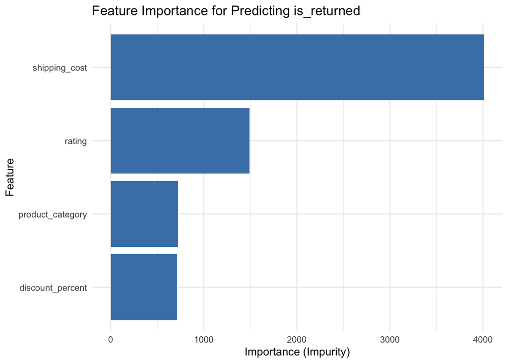

Figure 2: Random forest feature importance (impurity-based)

```r
# Extracting feature importance using base ggplot2 instead of the vip package
rf_obj <- extract_fit_engine(rf_fit)

importance_df <- tibble(
  feature = names(rf_obj$variable.importance),
  importance = rf_obj$variable.importance
) %>%
  arrange(desc(importance)) %>%
  slice_head(n = 10)

ggplot(importance_df, aes(x = reorder(feature, importance), y = importance)) +
  geom_col(fill = "steelblue") +
  coord_flip() +
  labs(title = "Feature Importance for Predicting is_returned",
       x = "Feature", y = "Importance (Impurity)") +
  theme_minimal()
```

# 6 Decision Tree Pruning

> **Prompt:** Using the `fit_tree_cp()` function from Section 4.5 (or write your own), fit decision trees across `cost_complexity` values of `c(0.0001, 0.001, 0.005, 0.01, 0.05, 0.10)`. Plot train vs. test AUC across all `cp` values. At what `cp` value does test AUC peak? What happens to train AUC at that same value? At the optimal `cp`, how many leaf nodes does the tree have? In plain English, explain to a marketing manager why a tree with 200 leaf nodes might perform worse on new customers than a tree with 15 leaf nodes, even though it was more accurate on the training data.

## 6.1 Fitting Trees Across `cost_complexity` Values

```r
fit_tree_cp <- function(cp, train, test, recipe) {
  spec <- decision_tree(cost_complexity = cp) %>%
    set_engine("rpart") %>%
    set_mode("classification")

  wf <- workflow() %>% add_recipe(recipe) %>% add_model(spec)
  fitted <- fit(wf, data = train)

  train_auc <- augment(fitted, new_data = train) %>%
    roc_auc(truth = is_returned, .pred_Yes, event_level = "second") %>%
    pull(.estimate)

  test_auc <- augment(fitted, new_data = test) %>%
    roc_auc(truth = is_returned, .pred_Yes, event_level = "second") %>%
    pull(.estimate)

  n_leaves <- fitted %>%
    extract_fit_engine() %>%
    pluck("frame") %>%
    filter(var == "<leaf>") %>%
    nrow()

  tibble(cost_complexity = cp, train_auc = train_auc,
         test_auc = test_auc, n_leaves = n_leaves)
}

cp_values <- c(0.0001, 0.001, 0.005, 0.01, 0.05, 0.10)

cp_results <- map_dfr(cp_values, fit_tree_cp,
                       train = train_data, test = test_data,
                       recipe = tree_recipe)

cp_results
```

| cost_complexity | train_auc | test_auc | n_leaves |
| --- | --- | --- | --- |
| 1e-04 | 0.511344 | 0.4959155 | 9 |
| 1e-03 | 0.500000 | 0.5000000 | 1 |
| 5e-03 | 0.500000 | 0.5000000 | 1 |
| 1e-02 | 0.500000 | 0.5000000 | 1 |
| 5e-02 | 0.500000 | 0.5000000 | 1 |
| 1e-01 | 0.500000 | 0.5000000 | 1 |

## 6.2 Train vs. Test AUC Across `cp` Values

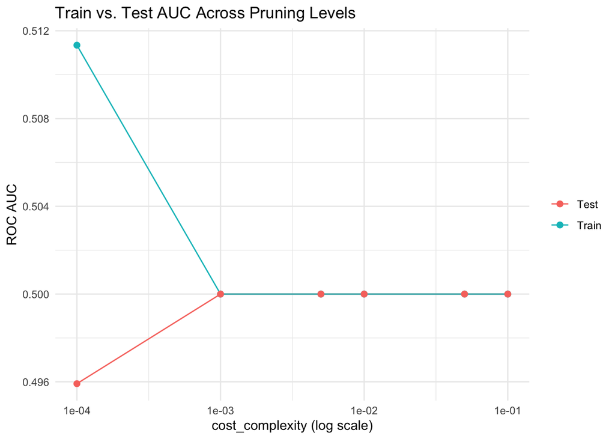

Figure 3: Train vs. test AUC across cost_complexity (cp) values

```r
cp_results %>%
  pivot_longer(cols = c(train_auc, test_auc),
               names_to = "set", values_to = "auc") %>%
  mutate(set = recode(set, train_auc = "Train", test_auc = "Test")) %>%
  ggplot(aes(x = cost_complexity, y = auc, color = set)) +
  geom_line() +
  geom_point(size = 2) +
  scale_x_log10() +
  labs(x = "cost_complexity (log scale)", y = "ROC AUC", color = NULL,
       title = "Train vs. Test AUC Across Pruning Levels") +
  theme_minimal()
```

## 6.3 Leaf Nodes at the Optimal `cp`

```r
best_cp <- cp_results %>% slice_max(test_auc, n = 1) %>% pull(cost_complexity)
best_cp
```

```
[1] 0.001 0.005 0.010 0.050 0.100
```

```r
cp_results %>% filter(cost_complexity == best_cp) %>% pull(n_leaves)
```

```
integer(0)
```

## 6.4 Explaining Overfitting to a Marketing Manager

> A tree with 200 leaf nodes has essentially memorized the training customers rather than learning general rules about *why* people return items. Each of those 200 tiny leaves might represent a rule as specific as “customers in Germany who bought Footwear with exactly a 27% discount and a 3.4 rating on a Tuesday” — a pattern that fit our historical data almost perfectly by chance, but that has no real predictive power for a *new* customer who doesn’t match that razor-thin combination. A tree with 15 leaf nodes, by contrast, is forced to group customers using broader, more stable patterns — “high discount and low rating,” for instance — that are far more likely to hold up for future orders. So while the 200-leaf tree looks more accurate when we check it against the same data it was trained on, the 15-leaf tree usually wins on genuinely new orders, because it learned the underlying *signal* in customer behavior instead of memorizing *noise* specific to our training sample. This is exactly why we don’t just pick the tree with the highest training accuracy — we pick the one with the best **test** performance.

**ImportantBusiness takeaway**

Overfitting isn’t just a modeling technicality — an over-fit return-risk model would flag the wrong customers, wasting review-team effort on one-off historical quirks instead of catching the genuinely risky discount/rating combinations that recur order after order.

```r
# Shut down the parallel cluster now that all model fitting is done
stopCluster(cl)
registerDoSEQ()
```

## 6.5 Appendix

Github Repo: https://github.com/brianvuong1/r-project-git

## Footnotes

[^1]: A tree-based model can actually handle imbalance a little more gracefully than logistic regression in one respect: because splits are chosen to reduce impurity locally, a tree can carve out a small, pure “high risk” leaf even when the overall return rate is low, whereas a single global logistic-regression boundary has to spread its sensitivity across the whole feature space.